# Visualizing Longitudinal Data Using brolgar

Biostat 203B

Dr. Hua Zhou @ UCLA

Jan 28, 2020

Adapted form the tutorial at http://brolgar.njtierney.com.

## Longitudinal data

[broglar](http://brolgar.njtierney.com) is an R package that helps **br**owse **o**ver **l**ongitudinal **d**ata **g**raphically and **a**nalytically in **R**.

## Installing `brolgar`

Install from GitHub:

```r
# install.packages("remotes")
remotes::install_github("njtierney/brolgar")
```

## An example longitudinal data

Load `tidyverse`, `brolgar` and `gghighlight`:

```r
library(tidyverse)
library(brolgar)
library(gghighlight)
```

The csv file `wages_pp.csv` contains a data set from the textbook *Applied Longitudical Data Analysis* (2003) by Singer and Willett. This data contains measurements on hourly wages by years in the workforce, with education and race as covariates.

```bash
head wages_pp.csv
```

```
## "id","lnw","exper","ged","postexp","black","hispanic","hgc","hgc.9","uerate","ue.7","ue.centert1","ue.mean","ue.person.cen","ue1"
## 31,1.491,0.015,1,0.015,0,1,8,-1,3.215,-3.785,0,3.215,0,3.215
## 31,1.433,0.715,1,0.715,0,1,8,-1,3.215,-3.785,0,3.215,0,3.215
## 31,1.469,1.734,1,1.734,0,1,8,-1,3.215,-3.785,0,3.215,0,3.215
## 31,1.749,2.773,1,2.773,0,1,8,-1,3.295,-3.705,0.08,3.215,0.08,3.215
## 31,1.931,3.927,1,3.927,0,1,8,-1,2.895,-4.105,-0.32,3.215,-0.32,3.215
## 31,1.709,4.946,1,4.946,0,1,8,-1,2.495,-4.505,-0.72,3.215,-0.72,3.215
## 31,2.086,5.965,1,5.965,0,1,8,-1,2.595,-4.405,-0.62,3.215,-0.62,3.215
## 31,2.129,6.984,1,6.984,0,1,8,-1,4.795,-2.205,1.58,3.215,1.58,3.215
## 36,1.982,0.315,1,0.315,0,0,9,0,4.895,-2.105,0,5.0965,-0.201500000000000,4.895
```

Read following variables into a tibble:  
- `id`: 1-888, for each subject.  
- `lnw`: natural log of wages, adjusted for inflation, to 1990 dollars.  
- `exper`: Experience - the length of time in the workforce (in years). The number of time points and values of time points for each subject can differ.  
- `ged`: when/if a graduate equivalency diploma is obtained.  
- `postexp`: change in experience since getting a ged (if they get one).  
- `black`: categorical indicator of race = black.  
- `hispanic`: categorical indicator of race = hispanic.  
- `hgc`: highest grade completed.  
- `uerate`: unemployment rates in the local geographic region at each measurement time.

```r
wages <- read_csv("wages_pp.csv") %>% select(1:8, 10)
wages %>% print(width = Inf)
```

```
## # A tibble: 6,402 x 9
##       id   lnw exper   ged postexp black hispanic   hgc uerate
##    <dbl> <dbl> <dbl> <dbl>   <dbl> <dbl>    <dbl> <dbl>  <dbl>
##  1    31  1.49 0.015     1   0.015     0        1     8   3.22
##  2    31  1.43 0.715     1   0.715     0        1     8   3.22
##  3    31  1.47 1.73      1   1.73      0        1     8   3.22
##  4    31  1.75 2.77      1   2.77      0        1     8   3.30
##  5    31  1.93 3.93      1   3.93      0        1     8   2.90
##  6    31  1.71 4.95      1   4.95      0        1     8   2.50
##  7    31  2.09 5.96      1   5.96      0        1     8   2.60
##  8    31  2.13 6.98      1   6.98      0        1     8   4.80
##  9    36  1.98 0.315     1   0.315     0        0     9   4.89
## 10    36  1.80 0.983     1   0.983     0        0     9   7.4
## # … with 6,392 more rows
```

## Turn data frame into a `tsibble`

We turn a regular data frame/tibble into a tidy time series data frame `tsibble` by identifying  
1. The **key** variable is the identifier of individuals.  
2. The **index** variable is the time component of your data.  
3. The **regularity** of the time interveral (index). Longitudinal data typically has irregular time periods between measurements, but can have regular measurements.

```r
wages <- as_tsibble(x = wages,
                    key = id,
                    index = exper,
                    regular = FALSE)
wages
```

```
## # A tsibble: 6,402 x 9 [!]
## # Key:       id [888]
##       id   lnw exper   ged postexp black hispanic   hgc uerate
##    <dbl> <dbl> <dbl> <dbl>   <dbl> <dbl>    <dbl> <dbl>  <dbl>
##  1    31  1.49 0.015     1   0.015     0        1     8   3.22
##  2    31  1.43 0.715     1   0.715     0        1     8   3.22
##  3    31  1.47 1.73      1   1.73      0        1     8   3.22
##  4    31  1.75 2.77      1   2.77      0        1     8   3.30
##  5    31  1.93 3.93      1   3.93      0        1     8   2.90
##  6    31  1.71 4.95      1   4.95      0        1     8   2.50
##  7    31  2.09 5.96      1   5.96      0        1     8   2.60
##  8    31  2.13 6.98      1   6.98      0        1     8   4.80
##  9    36  1.98 0.315     1   0.315     0        0     9   4.89
## 10    36  1.80 0.983     1   0.983     0        0     9   7.4
## # … with 6,392 more rows
```

## Display trajectories of a few individuals

`sample_n_keys()` and `sample_frac_keys()` to take a random sample of keys.

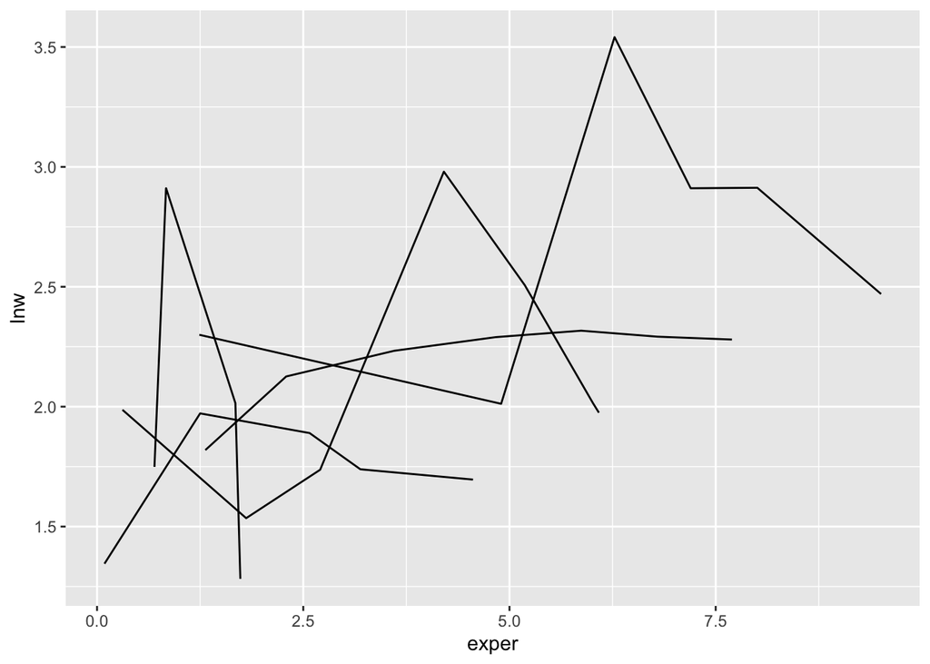

```r
set.seed(203)
wages %>%
  sample_n_keys(size = 5) %>%
  ggplot(aes(x = exper,
             y = lnw,
             group = id)) +
  geom_line()
```

`facet_sample()` allows you to specify the number of keys per facet, and the number of facets with `n_per_facet` and `n_facets`. By default, it splits the data into 12 facets with 3 per facet:

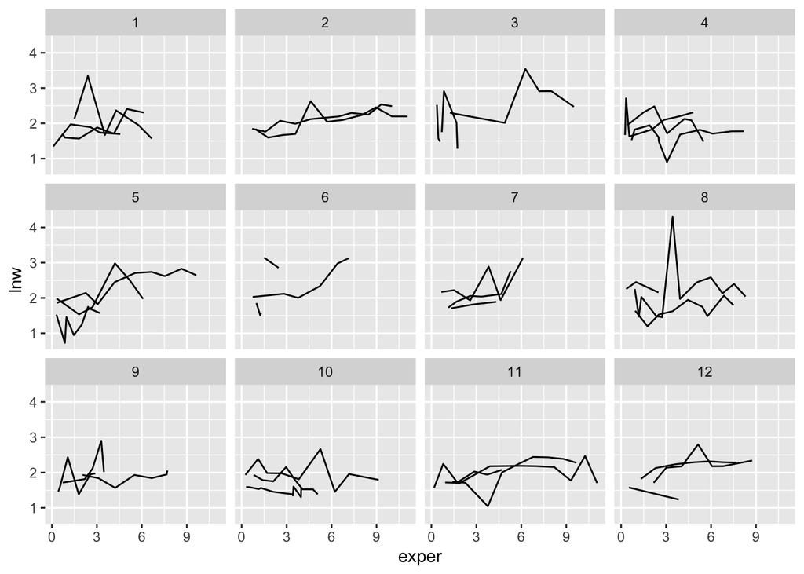

```r
set.seed(203)
ggplot(wages,
       aes(x = exper,
           y = lnw,
           group = id)) +
  geom_line() +
  facet_sample()
```

## Find features in longitudinal data

Five number summaries of wages for each individual:

```r
wages %>%
  features(lnw,
           feat_five_num)
```

```
## # A tibble: 888 x 6
##       id   min   q25   med   q75   max
##    <dbl> <dbl> <dbl> <dbl> <dbl> <dbl>
##  1    31 1.43   1.48  1.73  2.02  2.13
##  2    36 1.80   1.97  2.32  2.59  2.93
##  3    53 1.54   1.58  1.71  1.89  3.24
##  4   122 0.763  2.10  2.19  2.46  2.92
##  5   134 2.00   2.28  2.36  2.79  2.93
##  6   145 1.48   1.58  1.77  1.89  2.04
##  7   155 1.54   1.83  2.22  2.44  2.64
##  8   173 1.56   1.68  2.00  2.05  2.34
##  9   206 2.03   2.07  2.30  2.45  2.48
## 10   207 1.58   1.87  2.15  2.26  2.66
## # … with 878 more rows
```

Other feature functions include `feat_monotonic`, `feat_ranges`, `feat_spread`, `feat_three_num`, `n_obs`. For example, find those whose wages only increase or decrease with feat_monotonic:

```r
wages %>%
  features(lnw, feat_monotonic)
```

```
## # A tibble: 888 x 5
##       id increase decrease unvary monotonic
##    <dbl> <lgl>    <lgl>    <lgl>  <lgl>
##  1    31 FALSE    FALSE    FALSE  FALSE
##  2    36 FALSE    FALSE    FALSE  FALSE
##  3    53 FALSE    FALSE    FALSE  FALSE
##  4   122 FALSE    FALSE    FALSE  FALSE
##  5   134 FALSE    FALSE    FALSE  FALSE
##  6   145 FALSE    FALSE    FALSE  FALSE
##  7   155 FALSE    FALSE    FALSE  FALSE
##  8   173 FALSE    FALSE    FALSE  FALSE
##  9   206 TRUE     FALSE    FALSE  TRUE
## 10   207 FALSE    FALSE    FALSE  FALSE
## # … with 878 more rows
```

Find the number of observations per individual and summarize by bar plot:

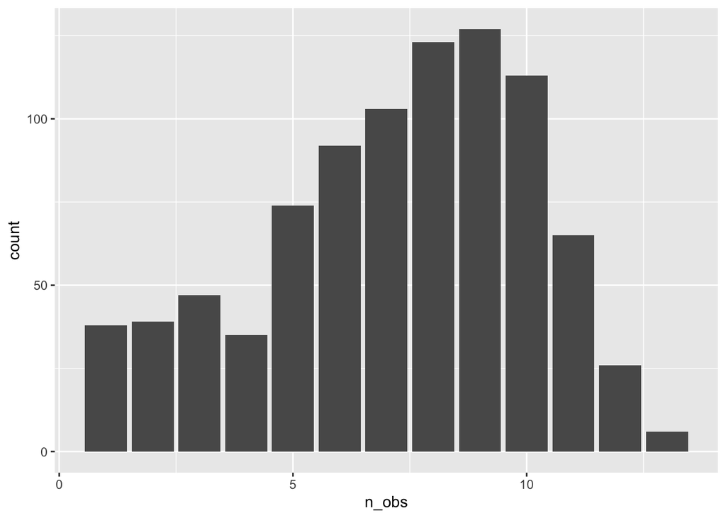

```r
wages %>%
  features(lnw, n_obs) %>%
  ggplot(aes(x = n_obs)) +
    geom_bar()
```

## Linking individuals back to the data

Once you have created these features, you can join them back to the data with a `left_join`:

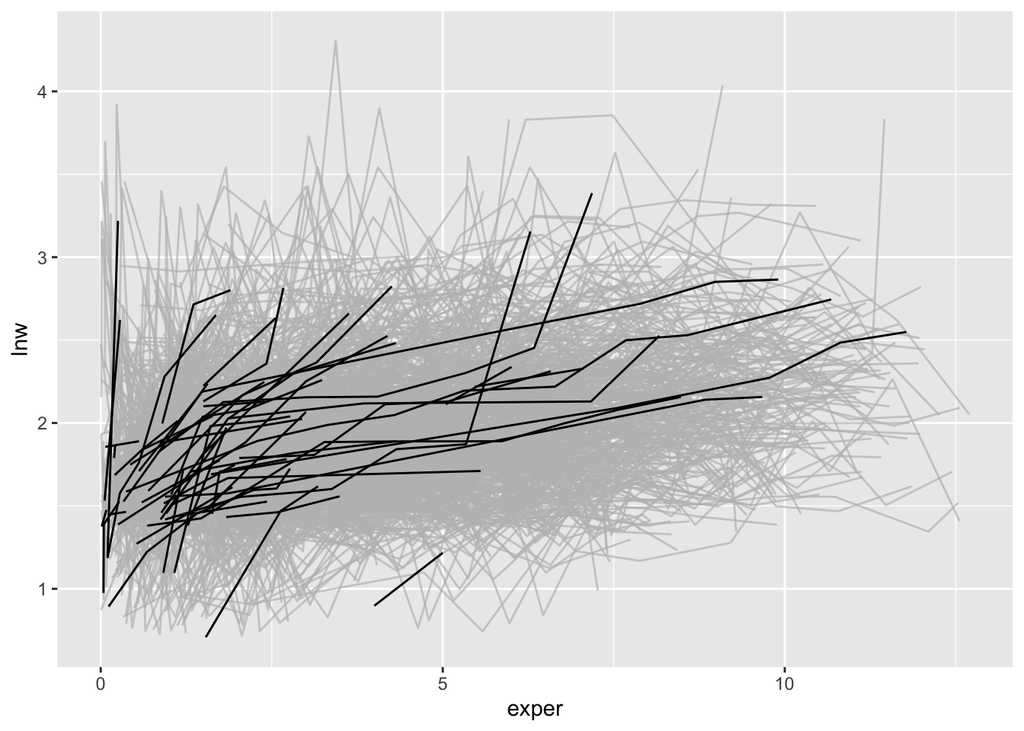

```r
wages %>%
  features(lnw, feat_monotonic) %>%
  left_join(wages, by = "id") %>%
  ggplot(aes(x = exper,
             y = lnw,
             group = id)) +
  geom_line() +
  gghighlight(increase)
```